# Logistic Regression

Modern Data Mining

## 0. Introduction

Read

- Chapter 4.1-4.3.4 (too skimpy about Logistic reg)
- Chapter 20.1-20.5 (Statistical Sleuth, OK, not enough either)

Table of Contents

0. Introduction
1. A quick EDA
2. Logistic Regressions (Illustrated with one predictor)
   - Link Function
   - Maximum Likelihood Estimator (MLE)
3. Inference for the Coefficients
   - Wald Intervals / Tests (through the MLE’s)
   - Likelihood Ratio Intervals / Tests (Chi-Squared Tests)
4. Multiple Logistic Regressions
   - Natural Extension
   - Model selection through backward selection or AIC (Aikake’s Information Criterion)

### Case Study: Framingham Heart Study fram_data:

1. Identify Coronary Heart Disease risk factors. Famous study: http://www.framinghamheartstudy.org/about-fhs/index.php
1. Data: 1,406 health professionals. Conditions gathered at the beginning of the study (early 50s). Both the original subjects and their next generations have been included in the study.

Variables:

`Heart Disease`, `AGE`, `SEX`, Blood pressures expressed as `SBP` and `DBP`, `CHOL` (cholesterol level), `FRW` (age and gender adjusted weight) and `CIG` (number of cigarettes smoked each week, self-reported.)

2. Goal:
- Identify risk factors
- Predict the probability of one with `Heart Disease`
3. In particular,

Predict Prob(HD=1) for a person who is:

| AGE | SEX | SBP | DBP | CHOL | FRW | CIG |
| --- | --- | --- | --- | --- | --- | --- |
| 45 | FEMALE | 100 | 80 | 180 | 110 | 5 |

4. `HD=1`: with Heart Disease and `HD=0`: No Heart Disease

## 1. A quick EDA

Read `Framingham.dat` as `fram_data`

```r
fram_data <- read.csv("Framingham.dat", sep=",", header=T, as.is=T)
str(fram_data)
names(fram_data)
summary(fram_data)
```

Rename and set variables to their correct type

```r
# names(fram_data)[1] <- "HD"
# fram_data$HD <- as.factor(fram_data$HD)
# fram_data$SEX <- as.factor(fram_data$SEX)
```

```r
fram_data %<>%   # make the following change to the data frame
   rename(HD = Heart.Disease.) %>%
   mutate(HD = as.factor(HD),
          SEX = as.factor(SEX))
```

Structure of the data

```r
str(fram_data)
```

Last row, which will be used for prediction. Notice that the response `HD` is missing here.

```r
tail(fram_data, 1)
```

We take out the female whose HD will be predicted, and save it to fram_data.new

```r
fram_data.new <- fram_data[1407,]
fram_data <- fram_data[-1407,]
```

```r
summary(fram_data)
```

Notice missing values in FRW and CIG. We won’t take those observations off the data set.

```r
sum(is.na(fram_data))
```

For simplicity we start with a simple question: **How does HD relate to SBP?**

```r
tapply(fram_data$SBP, fram_data$HD, mean)
```

On average SBP seems to be higher among HD = 1

We can see the distribution of `SBP` through back to back box plots. Again, SBP seems to be higher when HD = 1

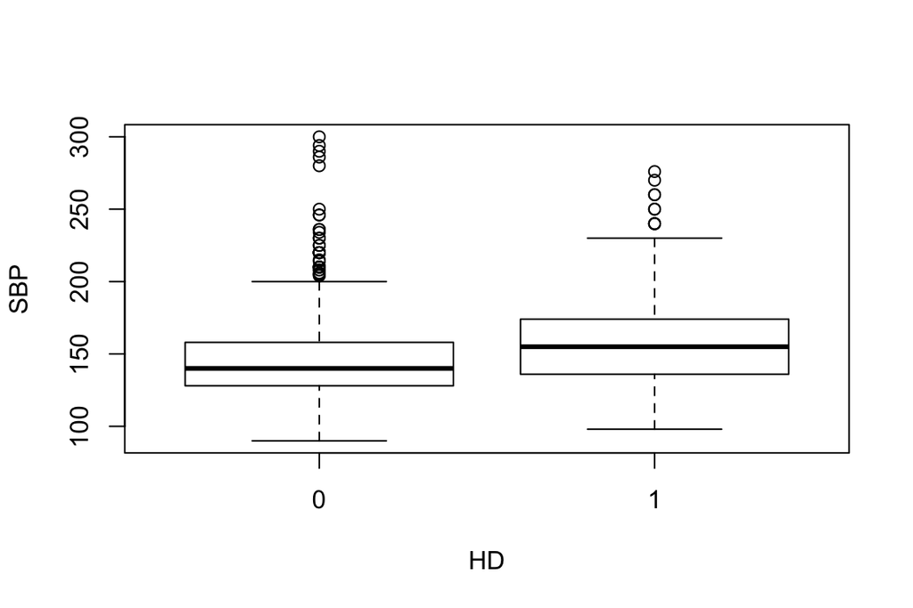

```r
plot(fram_data$HD, fram_data$SBP, ylab ="SBP", xlab = "HD")
```

Another way of producing the boxplots

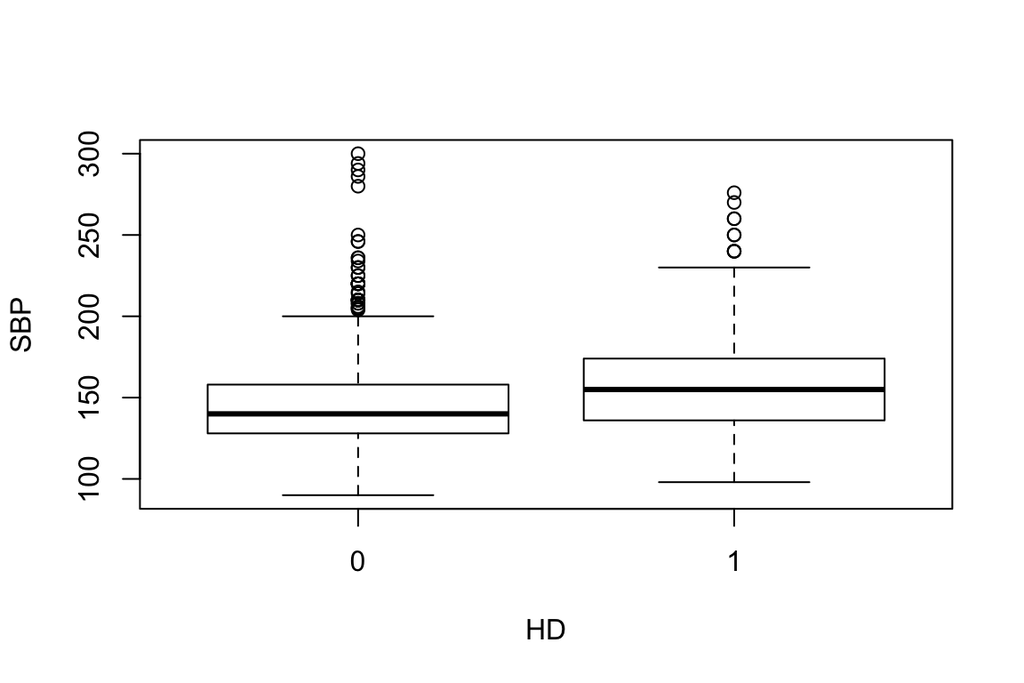

```r
boxplot(fram_data$SBP~fram_data$HD, ylab ="SBP", xlab = "HD")
```

Next we explore how proportions of HD = 1 relate to SBP

Standard plots:

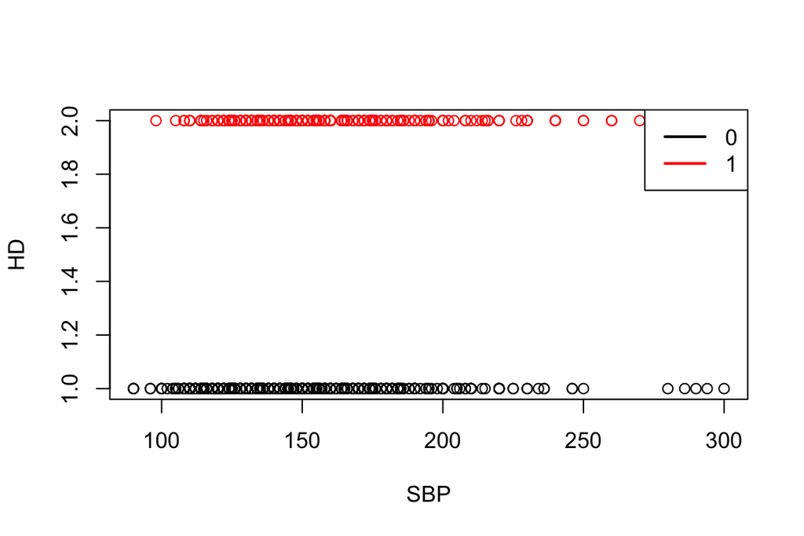

```r
plot(fram_data$SBP,
     fram_data$HD,
     col=fram_data$HD,
     xlab = "SBP",
     ylab = "HD")
legend("topright",
       legend=c("0", "1"),
       lty=c(1,1),
       lwd=c(2,2),
       col=unique(fram_data$HD))
```

Problems: many observations are over-plotted so they are not visible.

Solutions: use jitter() to spread out the observations with similar SBP values.

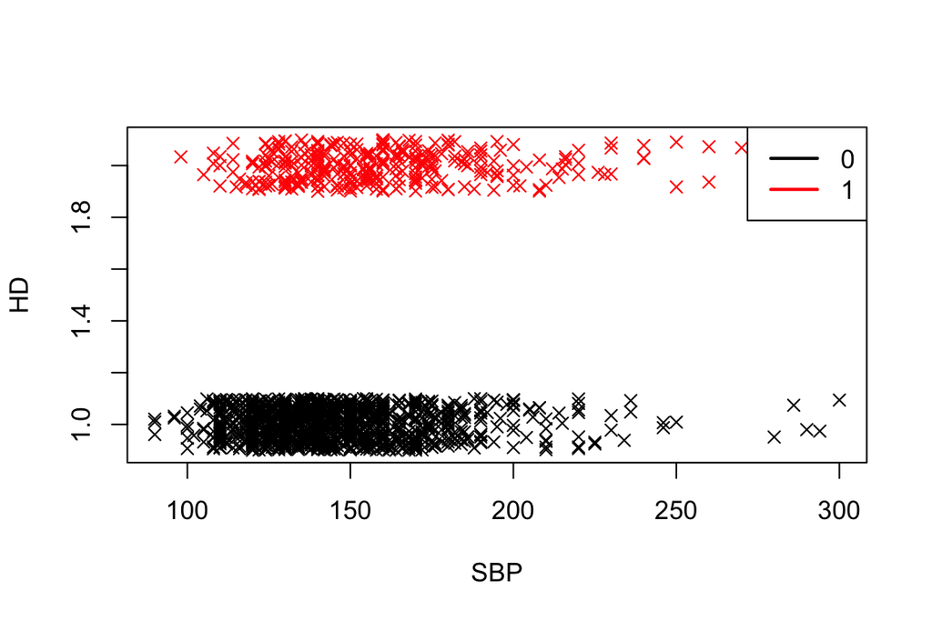

```r
plot(jitter(as.numeric(fram_data$HD), factor=.5) ~ fram_data$SBP,
     pch=4,
     col=fram_data$HD,
     ylab="HD",
     xlab="SBP")
legend("topright", legend=c("0", "1"),
       lty=c(1,1), lwd=c(2,2), col=unique(fram_data$HD))
```

It’s still hard to tell the proportion of each category given `SBP`.

Alternatively we could use stripchart() as follows:

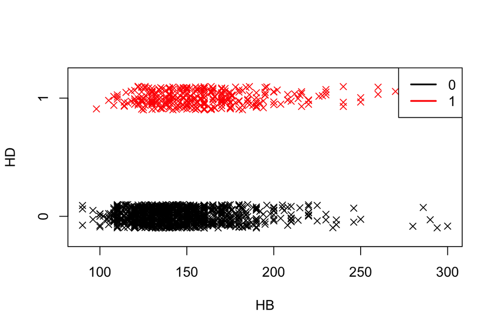

```r
stripchart(fram_data$SBP~fram_data$HD, method="jitter",
           col=c("black", "red"), pch=4,
           ylab="HD", xlab="HB")
legend("topright", legend=c("0", "1"),
       lty=c(1,1), lwd=c(2,2), col=unique(fram_data$HD))
```

All the plots above do not show the proportion of “1”’s vs. “0”’s as a function of SBP.

## 2. Logistic Regression of HD vs. SBP

### Logit model

Analogous to liner model in a regular regression, we model

$$P(Y=1\vert SBP) = \frac{e^{\beta_0 + \beta_1 SBP}}{1+e^{\beta_0+\beta_1 SBP}}$$
where $\beta_0$ and $\beta_1$ are unknown parameters.

Immediately we have

$$P(Y=0\vert SBP) = 1-P(Y=1\vert SBP) = \frac{1}{1+e^{\beta_0+\beta_1 SBP}}$$

$$\log\left(\frac{P(Y=1\vert SBP)}{P(Y=0\vert SBP)}\right)=\beta_0+\beta_1 \times SBP$$
**The above function is also termed as logit(P(Y=1|SBP))**

3. The interpretation of $\beta_1$ is the change in log odds ratio for a unit change in `SBP`.
4. Prob(Y=1|SBP) is a monotone function of `SBP`.

### Maximum likelihood methods

To estimate the unknown parameters $\beta$’s we introduce Likelihood Function of $\beta_0$ and $\beta_1$ given the data, namely the

**Probability of seeing the actual outcome in the data**:

Take a look at a piece of the data, randomly chosen from our dataset. We can then see part of the likelihood function.

```r
set.seed(2)
fram_data[sample(1:1406, 10), c("HD", "SBP")]
```

```
##      HD SBP
## 260   0 130
## 987   0 140
## 805   0 145
## 236   0 120
## 1324  1 130
## 1322  1 216
## 181   1 160
## 1166  0 130
## 655   1  98
## 769   0 136
```

We use this to illustrate the notion of likelihood function.

**MLE**: The maximizes $\hat \beta_1$ and $\hat \beta_0$ will be used to estimate the unknown parameters, termed as `Maximum Likelihood Estimators`:

$$\max _{\beta_0, \beta_1} \mathcal{Lik}(\beta_0, \beta_1 \vert Data)$$
Remark:

- $\hat \beta_0$ and $\hat \beta_1$ are obtained through $\max\log(\mathcal{Lik}(\beta_0, \beta_1 \vert D))$
- MLE can only be obtained through numerical calculations.
- `glm()` will be used to do logistic regression. It is very similar to `lm()` but some output might be different.

The default is logit link in `glm`

```r
fit1 <- glm(HD~SBP, fram_data, family=binomial(logit))
```

```r
summary(fit1, results=TRUE)
```

To see the prob function estimated by glm:

- logit = -3.66 + 0.0159 SBP
- $P(HD = 1 \vert SBP) = \frac{e^{-3.66+0.0159 \times SBP}}{1+e^{-3.66+0.0159 \times SBP}}$
- $P(HD = 0 \vert SBP) = \frac{1}{1+e^{-3.66+0.0159 \times SBP}}$
- Notice the prob of Y=1 is an increasing function of `SBP` since $\hat \beta_1 = .0159 > 0$.
- Unfortunately we do not have a nice interpretation of $\beta_1$ over `Prob (Y=1)`.

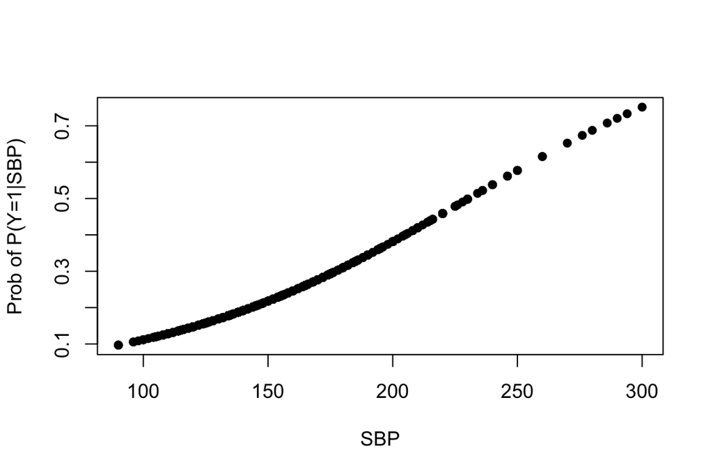

```r
par(mfrow=c(1,1))
plot(fram_data$SBP, fit1$fitted.values, pch=16,
     xlab="SBP",
     ylab="Prob of P(Y=1|SBP)")
```

Alternatively, we can plot the prob through $\frac{e^{-3.66+0.0159 \times SBP}}{1+e^{-3.66+0.0159 \times SBP}}$

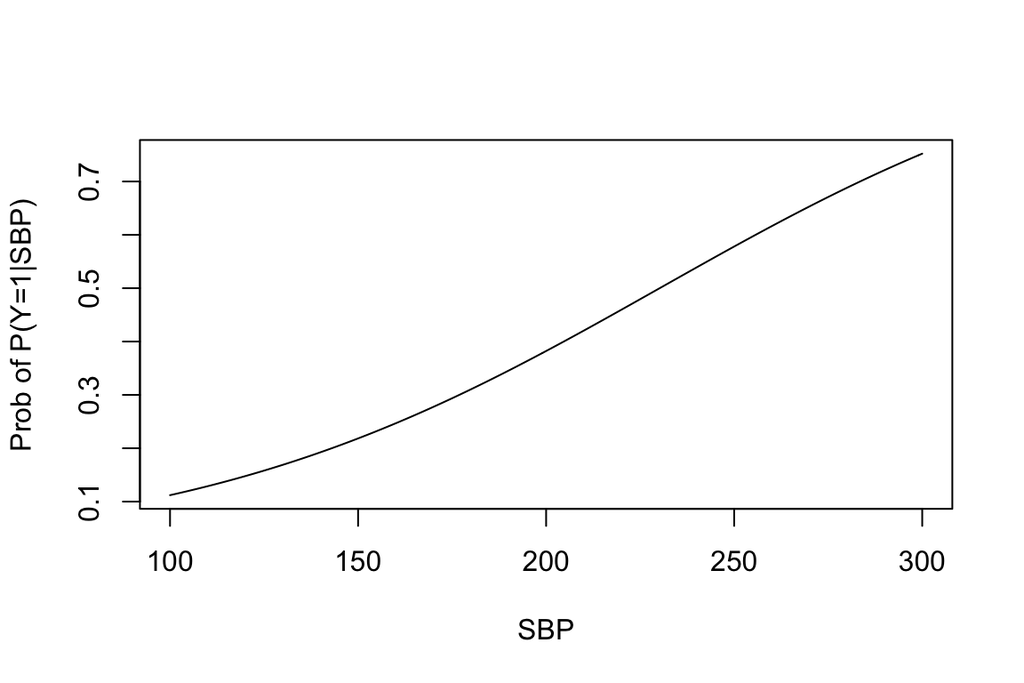

```r
x <- seq(100, 300, by=1)
y <- exp(-3.66+0.0159*x)/(1+exp(-3.66+0.0159*x))
plot(x, y, pch=16, type = "l",
     xlab = "SBP",
     ylab = "Prob of P(Y=1|SBP)" )
```

### Inference for the Coefficients

#### i. Wald intervals/tests (through the MLE’s)

Facts about MLE:

- The MLE’s are approximately normal and they are unbiased estimators of the $\beta$’s.
- The standard errors are obtained through information matrix
- The $z$ intervals and $z$ tests are valid for each $\beta_i$.

```r
summary(fit1)
```

Usual z-intervals for the coefficient’s (output from the summary)

```r
confint.default(fit1)
```

#### ii. Likelihood Ratio Tests

Similar to F tests in OLS (Ordinary Least Squares), we have Chi-Square tests to test if a collective set of variables are not needed.

Here:

$H_0: \beta_{SBP}=0$ $H_1: \beta_{SBP} \not= 0$

Facts about MLE: **Likelihood Ratio Tests**

- Under the $H_0$, the likelihood ratio (modified with log)
  $$\begin{split}
  \text {Testing stat} = \chi^2
  & = -2\times \log \frac{\max _{H_1} \mathcal{Lik}(\beta_0, \beta_1 \vert D)}{\max_{H_0} \mathcal{Lik}(\beta_0, \beta_1 \vert D)}\\
  &=-2\log(\mathcal{Lik}_{H_0}) - (-2\log(\mathcal{Lik}_{H_1}))\\
  &\sim \chi^2_{df=1}
  \end{split}$$
- Testing stat = Null Deviance - Residual Deviance. Here Deviance = $-2\log(\mathcal{L})$
- The p-value is done through $\chi^2$ distribution $p_{value}=P(\chi^2_{df} > \chi^2)$
- glm() outputs the two terms.

```r
summary(fit1)
```

```
##
## Call:
## glm(formula = HD ~ SBP, family = binomial(logit), data = fram_data)
##
## Deviance Residuals:
##     Min       1Q   Median       3Q      Max
## -1.6687  -0.7109  -0.6253  -0.5244   2.1072
##
## Coefficients:
##             Estimate Std. Error z value Pr(>|z|)
## (Intercept) -3.66342    0.34602 -10.587  < 2e-16 ***
## SBP          0.01590    0.00221   7.196 6.22e-13 ***
## ---
## Signif. codes:  0 '***' 0.001 '**' 0.01 '*' 0.05 '.' 0.1 ' ' 1
##
## (Dispersion parameter for binomial family taken to be 1)
##
##     Null deviance: 1485.9  on 1405  degrees of freedom
## Residual deviance: 1432.8  on 1404  degrees of freedom
## AIC: 1436.8
##
## Number of Fisher Scoring iterations: 4
```

Notice:

- Null deviance = 1485.9
- Residual deviance: 1432.8
- $\chi^2 = 1485.9-1432.8= 53.1$

Get the $\chi^2$ statistic

```r
chi.sq <- 1485.9-1432.8
```

$p_{value}$: from the likelihood Ratio test

```r
pchisq(chi.sq, 1, lower.tail=FALSE)
```

Or use anova/Anova{car} to get the $\chi ^2$ tests. Here the null hypothesis is that `SBP` is not needed or all (but the intercept) coefficients are 0

```r
anova(fit1, test="Chisq") #
```

Similar to the F-test in lm() set up.

```r
Anova(fit1)
```

**What does a** $\chi^2$** distribution looks like?**

- $\chi_1^{2} = z^2$
- $\chi_2^{2} = z_1^2 + z_2^2$, $z_1$ and $z_2$ are independently chosen z-scores

Different $\chi^2$ distributions

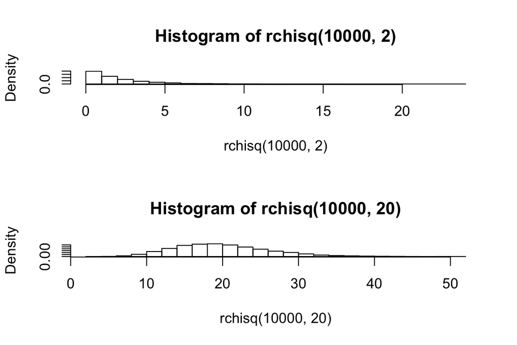

```r
par(mfrow=c(2,1))
hist(rchisq(10000, 2), freq=FALSE, breaks=20)
hist(rchisq(10000, 20), freq=FALSE, breaks=20)
```

**When df is getting larger,** $\chi^2$** distribution is approximately normal (why?)**

Inverting the likelihood ratio tests we can get confidence intervals for the coefficients. This should be similar to that obtained through Wald or z intervals but they are not the same.

```r
confint(fit1)
```

#### iii. Prediction

To do a prediction based on fit1 we plug in `SBP` value into the prob equation.

```r
fit1.predict <- predict(fit1, fram_data.new, type="response")
fit1.predict
```

## 3. Multiple Logistic Regression

To avoid problems, we will delete all cases with missing values

```r
fram_data.f <- na.omit(fram_data)
```

### a. With all the predictors

#### i. Full model

$$logit = \beta_0 + \beta_1 x_1 + \dots + \beta_p x_p$$
$$P(HD = 1) = \frac{e^{\beta_0 + \beta_1 x_1 + \dots + \beta_p x_p}}{1 + e^{\beta_0 + \beta_1 x_1 + \dots \beta_p x_p}}$$

- MLE’s will be obtained through maximize the Lik function
- Wald tests/intervals hold for each coefficient
- Likelihood Ratio tests hold for a set of predictors

With all the predictors

```r
fit2 <- glm(HD~., fram_data.f, family=binomial)
summary(fit2)
```

- The prob of Y=1 given all the factors is estimated as
  $$P(HD = 1) = \frac{e^{-9.33480 + 0.06249 \times AGE + 0.90610 I_{Male} + \dots + 0.01231 \times CIG}}{1 + {e^{-9.33480 + 0.06249 \times AGE + 0.90610 I_{Male} + \dots + 0.01231 \times CIG}}}$$
- Are all the risk factors not useful? Or all the $\beta$’s are 0 (Other then the intercept)

```r
chi.sq <- 1469-1343
chi.sq  #126
```

```r
pvalue <- pchisq(chi.sq, 7, lower.tail=FALSE)
pvalue
```

We reject the null hypothesis with any reasonable small $\alpha$.

Alternatively we may use anova to get the $\chi^2$ test by fitting the reduced model vs. the full model:

```r
fit0 <- glm(HD~1, fram_data.f, family=binomial) # null
```

It works only if two fits use same samples.

```r
anova(fit0, fit2, test="Chisq") #
```

```
## Analysis of Deviance Table
##
## Model 1: HD ~ 1
## Model 2: HD ~ AGE + SEX + SBP + DBP + CHOL + FRW + CIG
##   Resid. Df Resid. Dev Df Deviance  Pr(>Chi)
## 1      1392     1469.3
## 2      1385     1343.1  7   126.19 < 2.2e-16 ***
## ---
## Signif. codes:  0 '***' 0.001 '**' 0.01 '*' 0.05 '.' 0.1 ' ' 1
```

#### ii. Are CIG and FRW not needed?

Use Likelihood Ratio test to see if CIG and FRW are not needed in fit2

```r
fit3 <- update(fit2, .~. -CIG -FRW)
summary(fit3)
```

We first calculate the Chi-square stat directly:

```r
chi.sq.2 <- fit3$deviance-fit2$deviance
chi.sq.2
pchisq(chi.sq.2, 2, lower.tail=FALSE) # 0.06194729
```

We fail to reject the $H_0$ at $p < 0.05$ but we do reject the null at $alpha = .1$ since the p-value is < .1.

We could use anova…

```r
anova(fit3, fit2, test="Chisq")
```

### b. Model selection

#### i. Backward elimination

Backward selection is the easiest (without any packages) if p is not too large. As in lm, we eliminate the variable with the highest p-value.

```r
summary(fit2)
fit2.1 <- update(fit2, .~. -DBP)
```

Backward selection by kicking DBP (the one with largest p-value) out

```r
summary(fit2.1)
```

```r
fit2.2 <- update(fit2.1, .~. -FRW)
summary(fit2.2)
```

CIG didn’t really add much to decrease the residual deviance

```r
fit2.3 <- update(fit2.2, .~. -CIG)
summary(fit2.3)
```

Prediction for the subject using fit2.3

```r
fit2.3.predict <- predict(fit2.3, fram_data.new, type="response")
fit2.3.predict
```

Notice the difference between the predictions among fit2.3 and fit1!!!

0.11 based on SBP alone!

```r
predict(fit1, fram_data.new, type="response") #
```

#### ii. AIC through bestglm()

$$AIC = - 2\log(\mathcal{L}) + 2d$$
Where $d$: total number of the parameters. We are looking for a model with small AIC.

All predictors

```r
fit2 <- glm(HD~., fram_data.f, family=binomial)
summary(fit2)
```

In fit2: Residual Deviance= $-2\log(\mathcal{L})$, so AIC = $-2\log(\mathcal{L}) + 2d$ = Residual deviance + 2*8 = 1343.1 + 16 = 1359.1

Which model(s) gives us the smallest AIC?

**bestglm()** will be used

- the syntax is similar to that from leaps.
- we know less well about bestglm comparing with that of regsubsets

Get the design matrix without 1’s and HD.

```r
Xy <- model.matrix(HD ~.+0, fram_data.f)
```

Attach y as the last column.

```r
Xy <- data.frame(Xy, fram_data.f$HD)
```

```r
str(Xy)
```

```r
fit.all <- bestglm(Xy, family = binomial, method = "exhaustive", IC="AIC", nvmax = 10)
names(fit.all)
```

List the top 5 models. In the way any one of the following model could be used.

```r
fit.all$BestModels
```

Fit the best model which is the same as

```r
summary(fit.all$BestModel)
```

```r
summary(glm(HD~AGE+SEX+SBP+CHOL+FRW+CIG, family=binomial, data=fram_data.f))
```

#### iii. More models

- Extend models to include iterations

Are there interaction effects of SBP by SEX? or AGE by SEX?

```r
Anova(glm(HD ~ AGE + SBP + SEX + SBP*SEX + AGE * SEX, fram_data, family = binomial))
```

- What about a model treating CIG as a categorical variable?